# 人工智慧 進階課程 - Deep Learning- Capsule Networks Part- 01 - An introduction to Capsule Network - Python Tutorial

''' 人工智慧- 進階課程 A.I Tutorials - 進階課程 Advanced Course - Deep Learning 教程 ''' 05 - 深度學習 教程 課程 20 - Deep Learning- Capsule Networks Part- 01 - An introduction to Capsule Network 程式範例 - MNIST 手寫數字 辨識 - CNN / Capsule Network ''' ''' >> 資料準備 >> 你我互動學習園地- 進階課程 Advanced Course >> https://interactiveuandmetutorialsac.weebly.com/ >> 你我互動學習園地 >> https://interactiveuandmetutorials.weebly.com/ >> Python 程式語言 設計 >> https://pythonprogrammingtutorials.weebly.com/ >> 課程 20 - 目錄結構 課程 20－Machine Learning- Capsnets Part -01.ipynb ├ ├── datasets/ ├ ├── cifar.py ├ ├── fashion_mnist.py ├ ├── mnist.py ├ ├── utils.py ├ └── visualization.ipynb ├── images ├ ├── capsule_archi.png ├ ├── mnist_CNN_history.png ├ ├── mnist_CNN_history_light.png ├ ├── mnist_history.PNG ├ ├── mnist_history_light.png ├ └── training_archi.png ├ ├── keras_capsnet ├ ├── layer ├ ├ └── capsnet.py ├ ├── activations.py ├ └── losses.py ├ ├── keras_lropt ├ └── callbacks.py ├ ├── NoUI ├ ├── cifar_NoUI.py ├ └── mnist.py ├ └── utils.py ''' ''' - 深度學習 之父 - Geoffrey Hinton - Deep Learning 深度學習的 - 創始人之一 - 眾多模型 和 算法 Algorithms 的 發明者 '''

[figure not shown]

```python
- Hinton 和 他的 團隊

    - 發表 兩篇論文
        - Published Two Paper
    - 膠囊 Capsules
        - 新型的 神經網絡
        - new type of Neural Network

    - 膠囊之間的 動態路由
        - Dynamic Routing Between Capsules
            - https://arxiv.org/abs/1710.09829

    - EM 佈線 矩陣膠囊
        - MATRIX CAPSULES WITH EM ROUTING
        - https://openreview.net/pdf?id=HJWLfGWRb
```

''' - Capsule Networks - 膠囊 Capsules 引入了一個 新的 構建基塊 New Building Block - 可用於 深度學習中 - 以更好地建模神經網絡 - 內部的 層次關係 Hierarchical Relationships - 提出了一種訓練 - 一個簡單的 數據集 - 訓練 - 由膠囊 Capsules 組成的 - 網絡 Capsules Network - CapsNets 的方法 - 並成功地 - 在這一個簡單的數據集上 - 進行了訓練 - 錯誤率 Error Rate 降低了 45％ - 非常令人鼓舞的 - 儘管如此 當前的 結果比其他現代深度學習模型要 - 慢得多 slower - 時間 Time - 膠囊網絡 capsule networks 是否可以 更快速 及有效地訓練 - 此外 - 需要查看它們是否適用 - 於更多 更困難的數據集 以及 不同領域 - Difficult Data Sets and in Different Domains '''

[figure not shown]

''' >> 膠囊之前，需要回顧一下 CNN - 卷積神經網絡 - Convolutional Neural Networks '''

[figure not shown]

''' - 卷積神經網絡 - 重要 缺點 Drawbacks - 1. CNN (卷積神經網絡) 很強 - 深度學習的 - 30項 驚人 應用 - 30 AMAZING APPLICATIONS OF DEEP LEARNING - http://www.yaronhadad.com/deep-learning-most-amazing-applications/ - 深度學習 - 如此流行的原因之一 - 2. 但是 , 有其局限性 Limitation - 根本的缺陷 - Fundamental Drawbacks. - 例如 - 兩個圖片 - 都是相似的，因為它們 都 - 包含 相似的元素 - 臉 - 橢圓形 oval - 兩隻眼睛 - 鼻子 - 嘴巴 CNN - 僅考慮 - 這些對象的存在 - 就可以很強地 - 表明圖像中 - 存在人臉 - 組件之間 Objects - Face in the Image - 的方向 Orientational 和 相對空間關係 Relative Spatial - 但對於 CNN 並不是很重要 '''

[figure not shown]

- 對於 CNN - 兩個圖片都是 相似的 - 因為都包含 相似的元素 Similar Elements - 上面的圖示/例中 - 圖片中僅存在兩隻眼睛，嘴巴和鼻子並不意味著有一張臉 - 還需要知道 - 這些對像 如何相對於 - 彼此定向 Oriented relative to each others

```python
-　CNN(convolutional neural networks)　-　如何運作

    -　課程 00 - Deep Learning- An Introduction to Convolutional Neural Networks (CNN) - 卷積神經網絡 介紹 - Part1
    -　https://interactiveuandmetutorials.weebly.com/3550631243-00---deep-learning--an-introduction-to-convolutional-neural-networks-cnn---213673130931070321473217832097-2017132057---part1.html
```

```python
from IPython.display import HTML
HTML("""<iframe width="560" height="315" src="https://www.youtube.com/embed/Yij_HyaTMWM" frameborder="0" allowfullscreen></iframe>""")
```

[video not shown]

```python
-　主要成分 是 卷積層 Convolutional Layer
    　- 主要的工作
        - 檢測圖像像素中的 - Image Pixels
            - 重要特徵 - Detect Important Features

      - 較深的圖層 -更靠近輸入
        - 將學習檢測 - 簡單特徵
                    - 例如 邊緣 Edges 和 顏色漸變 Color Gradients,
        - 而 較高的圖層
            - 將把簡單特徵組合 - 為更複雜的特徵
            - 最後
                - 網絡頂部的密集層 Top of Dense Layers
                - 將結合非常高級的功能 High Level Features
                - 並產生分類預測 classification Predictions
```

''' - 重要的是 - 高級特徵 Higher-Level Features - 將低級特徵 Lower-Level Features 作為加權總和 Weigths Sum - 前一層的激活 Activations與下一層神經元的權重相乘並相加 - 然後傳遞給 激活非線性 Nonlinearity - 在此中，組成更高級別特徵的 Higher Level Feature - 簡單特徵 Simpler Features之間 - 沒有 姿勢 Pose(平移 Translational 和旋轉 Rotational) - 相對應關係 Relationship - 解決此問題的方法 - 使用 - 最大池化 - Max Pooling - 或 - 連續卷積層 - Successive Convolutional Layers - 這些層會 - 減小流經網絡的數據的 空間大小 Spacial Size - 從而 增加 高層神經元的 - 視野 Field Of View - 從而使它們 - 能夠 檢測神經元中的高階特徵 - Higher Order Features - Max pooling - 讓卷積網絡 Convolutional Networks 工作性能 出色 - 的關鍵 - 但是，不要被它的性能所迷惑 - 儘管 CNN 的性能 比之前的任何模型都要好 - 但是 最大池化 Max Pooling - 卻會丟失 有價值 的信息 - Valuable Information '''''' - Hinton 本人表示 - 積神經網絡中 - 使用的池化操作 , 是一個 很大的錯誤 - 它運行良好的事實是一場災難 - Hinton himself stated that - the fact that max pooling is working so well is a big mistake - and a disaster - 關鍵問題 - Key Problem - 當然，可以省去最大緩衝池 - 並且使用傳統的 CNN 仍然可以獲得良好的結果 - 但是 它們 仍然 不能解決 關鍵問題 "卷積神經網絡 - 的內部數據表示 - 未考慮簡單 - 對象 與 復雜對象之間 - 的重要 空間層次結構 " Internal data representation of a convolutional neural network - does not take into account important spatial hierarchies - between simple and complex objects." - 上面的圖示/例中 - 圖片中僅存在兩隻眼睛，嘴巴和鼻子並不意味著有一張臉 - 還需要知道 - 這些對像 如何相對於 - 彼此定向 Oriented Relative To Each Others '''

''' >> 逆向 圖形方法 - Inverse Graphics Approach - 將 3D 圖相 Image 編碼 - 為 神經網絡 - Inverse Graphics Approach - Hardcoding 3D World into a Neural Net - https://en.wikipedia.org/wiki/3D_computer_graphics - 計算機圖形學 - 涉及 從幾何數據的某些內部層次結構 - 表示構造 可視圖像 - 該表示的結構 - 需要 - 考慮對象的相對位置 - 內部表示 形式 - 以幾何對象和矩陣的陣列形式存儲在電腦 記憶體中 - 這些矩陣表示這些對象的相對位置和方向 - 然後，專用 3D 軟件 - 將其表示 /並轉換為 圖像 - 稱為渲染 /效果圖 Rendering '''

[figure not shown]

''' - 計算機圖形學 Computer Graphics - 採用 對象的內部表示 Internal Representation Of Objects - 形式並 生成圖像 Image - 人類的大腦 - 則相反 - 膠囊網絡 Capsule Networks - 遵循 與大腦 類似 的方法 - 欣頓 Hinton 認為 - 大腦 Brains實際上 與 Rendering 相反 - 稱其為 逆向圖形 - Inverse Graphics >> http://helper.ipam.ucla.edu/publications/gss2012/gss2012_10754.pdf - 眼睛接收到的視覺信息中 - 它們 解構了 周圍世界的層次 - 並試圖 - 將其與已經學習的模式 和 存儲在大腦中的 - 關係相匹配 - 這就是 - 識別發生的方式 Recognition Happens - 關鍵思想 - 是大腦中 Brain - 對象的表示 Representation Of Objects - 不依賴於視角 View Angle '''''' - 如何在 神經網絡 Neural Network 內部 - 建立 Modeling - 具有這些 層次關係 Hierarchical Relationships - 答案 - 來自 計算機圖形學 Computer Graphics - 在 3D 圖形中 - 3D 對象之間的關係 Relationships Between 3D Objects - 可以用 姿態 Pose 表示 - 實質/際 上就是 - 平移 Translation - https://en.wikipedia.org/wiki/Translation_(geometry) - 旋轉 Rotation - https://en.wikipedia.org/wiki/Rotation_(mathematics) '''''' - Hinton 認為 - 為了正確 進行分類 Classification 和 對象識別 Object Recognition - 重要的是要保留 - 對象部分之間的 分層 姿勢關係 - Hierarchical Pose Relationships Between Object Parts - 這是理解 膠囊理論 的關鍵 - Capsule Theory - 結合了對象之間的相對關係 - 以數字形式表示為 - 4D 姿態矩陣 Pose Matrix http://homepages.inf.ed.ac.uk/rbf/CVonline/LOCAL_COPIES/MARBLE/high/pose/express.htm '''''' - 如果 - 將這些關係構建到 數據的內部表示中 - 模型 Model 就 很容易理解 - 所看到的事物只 - 是以前所見事物的 - 另一種觀點 Another View - 下圖示/例中 - 可以輕鬆地識別出 - 是自由女神像 - 即使所有圖像 - 從不同角度展示了它 - 這是 因為大腦中 - 自由女神像的內部 表示形式 - 不依賴於視角 - 可能從未見過這些圖像的 確切圖片 - 但是 仍然立即知道它是什麼 - 即使所有照片 - 從不同角度 拍攝的 - 大腦也 - 可以輕鬆識別出 - 這是同一物體 '''

[figure not shown]

''' - CNN 不具備此功能 - CNN 而言，此任務 Task 確實很困難 - 因為它沒有對 3D空間 3D Space - 的 內在了解 - CapsNet - 這些關係 - 被明確建模立在模型 Modeled - The paper 論文 - that uses this approach was able to cut error rate by 45% - 膠囊方法 Capsule Approach - 另一個好處是 - 僅使用 CNN 使用的 部分數據 - only using a fraction of the data that a CNN would use - 就能學會獲得 最新的性能 - 理論上 - 膠囊理論 更接近 人腦 在實踐中的行為 - The Capsule Theory - is much closer to - what the human brain does in practice - 為了 學會區分數字 - 人腦 只需要 看幾個例子 Examples- 最多兩個 - 另一方面 - CNN 需要成千上萬的例子 Examples - 來獲得非常好的性能 '''

''' - 這個想法真的很簡單，以前沒有人想到過 - 欣頓 Hinton - 數十年來一直在思考這一問題 - 原因之一 - 是計算機在 2012年 之前 - GPU 的早期時代 Pre-GPU-based - 還不夠強大 - 另一個原因 - 沒有一種 演算法 Algorithm - 可以 成功 實現 - 學習膠囊網絡 Capsule Network - 以相同的方式人工神經元始於1940年代 - 但直到1980年代中期 - 出現 反向傳播算法 Backpropagation Algorithm - 並成功地 - 訓練了深層網絡 Deep Networks '''''' - Hinton 之前 已經提到過 - 但是直到現在還沒有算法可以使它 - 起作用 - 該演算法 稱為 - 膠囊之間 的 動態路由 - Dynamic Routing Between Capsules - 該演算法 允許膠囊 Capsules - 彼此通信 - 並創建 - 類似於計算機圖形學中場景圖 的表示 - Algorithm allows Capsules - to communicate with each other and - create representations similar to scene graphs - in computer graphics '''

[figure not shown]

```python
- 膠囊網絡比其他模型要好得多
    - 因為可以告訴我們頂部和底部的圖像屬於同一類
    - 只是視角不同
        - 論文
            - 將錯誤率降低了 - 45%
```

# 膠囊網絡(CapsNets)

```python
from IPython.display import HTML
HTML("""<iframe width="560" height="315" src="https://www.youtube.com/embed/pPN8d0E3900" frameborder="0" allowfullscreen></iframe>""")
```

[video not shown]

# CNN - mnist

```python
import platform
```

```python
!python -V
platform.python_version()
```

```
Python 3.7.3
```

```
'3.7.3'
```

```python
import keras
keras.__version__
```

```
'2.2.4'
```

```python
import tensorflow
import keras
print("Platform: {}".format(platform.platform()))
print("Tensorflow version: {}".format(tensorflow.__version__))
print("Keras version: {}".format(keras.__version__))
```

```
Platform: Windows-10-10.0.18362-SP0
Tensorflow version: 1.14.0
Keras version: 2.2.4
```

''' - STEP 1 - Import 載入相關 函式庫 - Import the required libraries '''

```python
import numpy as np
import seaborn as sns
from keras.models import Sequential
from keras.layers.convolutional import Convolution2D, MaxPooling2D
from keras.layers.core import Dense, Reshape, Activation, Flatten
from keras.layers import Input, BatchNormalization, Dropout
from keras.losses import categorical_crossentropy
from keras.optimizers import Adam, SGD
from keras.utils import plot_model, multi_gpu_model

from utils import LossHistory, plotHistory, visualization_data, rotation_accuracy
from datasets.mnist import dataGenerator
from keras_lropt.callbacks import LRFinderAuto as LRFinder
```

# Parameters

```python
num_class = 10
input_shape = (28, 28, 1)

m_train = 60000
m_test  = 10000

batch_size = 32

data_augmentation = {
    'width_shift_range': 2,
    'height_shift_range': 2
}
```

# Dataset

```python
trainGenerator = dataGenerator('train', batch_size=batch_size, reshape=False, **data_augmentation)
testGenerator = dataGenerator('test', batch_size=batch_size, reshape=False)
```

# Model

```python
model = Sequential([
    Convolution2D(filters=64, kernel_size=(3, 3), padding='same', input_shape=input_shape),
    MaxPooling2D(),
    BatchNormalization(),
    Activation('relu'),

    Convolution2D(filters=64, kernel_size=(3, 3), padding='same'),
    MaxPooling2D(),
    BatchNormalization(),
    Activation('relu'),

    Convolution2D(filters=64, kernel_size=(3, 3), padding='same'),
    MaxPooling2D(),
    BatchNormalization(),
    Activation('relu'),

    Flatten(),
    Dropout(0.2),
    Dense(10, activation='softmax')
])
```

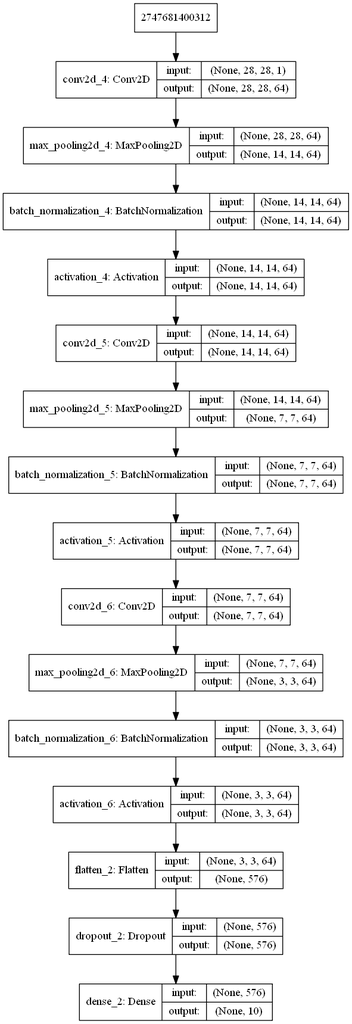

```python
# Plot model graph
plot_model(model, show_shapes=True, show_layer_names=True, to_file='mnist_CNNmodel.png')
from IPython.display import Image
Image(retina=True, filename='mnist_CNNmodel.png')
```

```python
model.summary()
```

```
_________________________________________________________________
Layer (type)                 Output Shape              Param #
=================================================================
conv2d_4 (Conv2D)            (None, 28, 28, 64)        640
_________________________________________________________________
max_pooling2d_4 (MaxPooling2 (None, 14, 14, 64)        0
_________________________________________________________________
batch_normalization_4 (Batch (None, 14, 14, 64)        256
_________________________________________________________________
activation_4 (Activation)    (None, 14, 14, 64)        0
_________________________________________________________________
conv2d_5 (Conv2D)            (None, 14, 14, 64)        36928
_________________________________________________________________
max_pooling2d_5 (MaxPooling2 (None, 7, 7, 64)          0
_________________________________________________________________
batch_normalization_5 (Batch (None, 7, 7, 64)          256
_________________________________________________________________
activation_5 (Activation)    (None, 7, 7, 64)          0
_________________________________________________________________
conv2d_6 (Conv2D)            (None, 7, 7, 64)          36928
_________________________________________________________________
max_pooling2d_6 (MaxPooling2 (None, 3, 3, 64)          0
_________________________________________________________________
batch_normalization_6 (Batch (None, 3, 3, 64)          256
_________________________________________________________________
activation_6 (Activation)    (None, 3, 3, 64)          0
_________________________________________________________________
flatten_2 (Flatten)          (None, 576)               0
_________________________________________________________________
dropout_2 (Dropout)          (None, 576)               0
_________________________________________________________________
dense_2 (Dense)              (None, 10)                5770
=================================================================
Total params: 81,034
Trainable params: 80,650
Non-trainable params: 384
_________________________________________________________________
```

# Training

```python
model.compile(optimizer=Adam(lr=1e-4), loss=categorical_crossentropy, metrics=['accuracy'])
```

```
W1212 14:18:22.991168 73308 deprecation_wrapper.py:119] From C:\Users\calvi\Anaconda3\lib\site-packages\keras\optimizers.py:790: The name tf.train.Optimizer is deprecated. Please use tf.compat.v1.train.Optimizer instead.
```

```python
history = LossHistory(metrics=('loss', 'acc'))
```

```python
%%time
hist = model.fit_generator(trainGenerator,
                                    steps_per_epoch=m_train // batch_size,
                                    epochs= 10,
                                    validation_data=testGenerator,
                                    validation_steps=m_test // batch_size,
                                    verbose=1,
                                    callbacks=[history])
```

```
W1212 14:18:37.885283 73308 deprecation.py:323] From C:\Users\calvi\Anaconda3\lib\site-packages\tensorflow\python\ops\math_grad.py:1250: add_dispatch_support.<locals>.wrapper (from tensorflow.python.ops.array_ops) is deprecated and will be removed in a future version.
Instructions for updating:
Use tf.where in 2.0, which has the same broadcast rule as np.where
```

```
Wall time: 16min 27s
```

```python
model.save('mnist_CNNmodel.h5')  # creates a HDF5 file 'my_model.h5'
```

```python
hist.history['acc']
```

```
[0.9091666666666667,
 0.9764833333333334,
 0.9832666666666666,
 0.9862833333333333,
 0.98835,
 0.98965,
 0.9910666666666667,
 0.9906833333333334,
 0.9922166666666666,
 0.99235]
```

```python
hist.history['loss']
```

```
[0.34456086736917496,
 0.0874360506253938,
 0.0597470114008834,
 0.04758235091554622,
 0.04036059307853381,
 0.03513865236456817,
 0.03118187523431455,
 0.02904112549998487,
 0.025025966274016535,
 0.024626226877390096]
```

```python
hist.history['val_loss']
```

```
[0.06979995083887704,
 0.04205188684368784,
 0.03403985768670207,
 0.027891476955160165,
 0.023561754964671753,
 0.021788300971394437,
 0.021424523129817068,
 0.021769549904400887,
 0.02149120837487026,
 0.018501680511561744]
```

```python
hist.history['val_acc']
```

```
[0.9826722756410257,
 0.9879614767255217,
 0.9903691813804173,
 0.9916733547351525,
 0.993077849117175,
 0.9932784911717496,
 0.9932784911717496,
 0.9937800963081862,
 0.9925762439807384,
 0.9936797752808989]
```

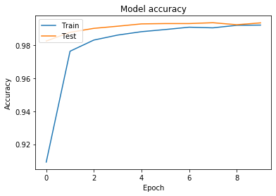

[figure not shown]

```python
import matplotlib.pyplot as plt

# Plot training & validation accuracy values

fig=plt.figure()
plt.plot(hist.history['acc'])
plt.plot(hist.history['val_acc'])

plt.title('Model accuracy')
plt.ylabel('Accuracy')
plt.xlabel('Epoch')
plt.legend(['Train', 'Test'], loc='upper left')
plt.show()

fig.savefig('mnist_CNNmodel1.png')


# Plot training & validation loss values
fig=plt.figure()
plt.plot(hist.history['loss'])
plt.plot(hist.history['val_loss'])
plt.title('Model accuracy')
plt.ylabel('Accuracy')
plt.xlabel('Epoch')
plt.legend(['Train', 'Test'], loc='upper left')
plt.show()

fig.savefig('mnist_CNNmodel2.png')
```

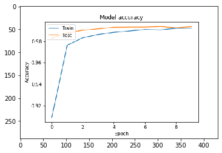

```python
import matplotlib.image as img
im1 =img.imread('mnist_CNNmodel1.png')
plt.imshow(im1)
```

[figure not shown]

```python
import matplotlib.image as img
im2 =img.imread('mnist_CNNmodel2.png')
plt.imshow(im2)
```

# Evaluation on augmented data

## Accuracy

Test accuracy for different rotations on test data

```
Test acc [0.0°]:	0.994
Test acc [20.0°]:	0.982
Test acc [40.0°]:	0.901
Test acc [60.0°]:	0.746
Test acc [80.0°]:	0.609
Test acc [100.0°]:	0.528
Test acc [120.0°]:	0.472
Test acc [140.0°]:	0.459
Test acc [160.0°]:	0.447
Test acc [180.0°]:	0.445
```

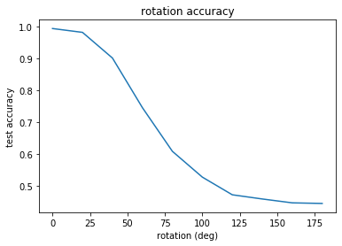

```python
rotation_accuracy(model, dataGenerator, m_test=m_test, batch_size=batch_size)
```

## Visualization

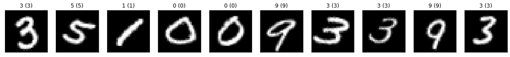

```python
n_image=10
data_augmentation = {'rotation_range': 30}

# Select data
testGenerator = dataGenerator('test', batch_size=n_image, reshape=False, **data_augmentation)
images, labels = next(testGenerator)

# Run inference
predictions = model.predict(images)

# Post-process data
labels = np.argmax(labels, axis=1)
predictions = np.argmax(predictions, axis=1)
images = images.reshape((-1, 28, 28))

visualization_data(images, labels, predictions)
```

# Capusle - mnist

```python
import numpy as np
import seaborn as sns
from matplotlib import pyplot as plt
from keras.models import Model, Sequential
from keras.layers.convolutional import Convolution2D, MaxPooling2D, AveragePooling2D
from keras.layers.core import Dense, Reshape, Dropout, Activation
from keras.layers import Input, BatchNormalization, GlobalAveragePooling2D, Flatten
from keras.losses import mean_squared_error, categorical_crossentropy
from keras.optimizers import Adam
from keras.utils import plot_model, multi_gpu_model

from utils import LossHistory, plotHistory, visualization_train, visualization_data, rotation_accuracy
from keras_capsnet.layer.capsnet import PrimaryCaps, Caps, CapsCNN, ClassesCaps, Mask
from keras_capsnet.losses import margin
from keras_capsnet.activations import squash
from datasets.mnist import dataGenerator
```

```python
# Plotting for dark theme
sns.set(context='paper', style='darkgrid', rc={'figure.facecolor':'white'}, font_scale=1.2)
```

# Parameters

```python
num_class = 10
input_shape = (28, 28, 1)

m_train = 60000
m_test  = 10000


batch_size = 16

data_augmentation = {
    'width_shift_range': 2,
    'height_shift_range': 2
}

test_augmentation = {
    'width_shift_range': 10,
    'height_shift_range': 10
}
```

# Dataset

```python
trainGenerator = dataGenerator('train', batch_size=batch_size, reshape=False, **data_augmentation)
testGenerator = dataGenerator('test', batch_size=batch_size, reshape=False)
```

# Model

```python
model = Sequential([
    Convolution2D(filters=128, kernel_size=(9, 9), padding='valid', activation='relu', input_shape=input_shape, name="Input"),
    Convolution2D(filters=32, kernel_size=(3, 3), padding='valid', activation="relu", strides=2, name="PrimaryCaps"),
    Activation(squash, name="Squash"),

    CapsCNN(16, kernel_size=(5, 5), routings=3, activation_caps=squash, name="ConvolutionalCaps"),

    Reshape((-1, 16), name='Flatten'),

    Caps(capsules=num_class, capsule_dim=12, routings=3, activation_caps=squash, name="Caps"),
    ClassesCaps(name='capsule'),
])
plot_model(model, show_shapes=True)
```

```
W1212 14:38:19.785630 73308 deprecation.py:506] From C:\Users\calvi\OneDrive\桌面\Capsulerecord\CapsNet-for-Keras-master\CapsNet-for-Keras-master\keras_capsnet\layer\capsnet.py:125: calling extract_image_patches (from tensorflow.python.ops.array_ops) with ksizes is deprecated and will be removed in a …
Instructions for updating:
ksizes is deprecated, use sizes instead
```

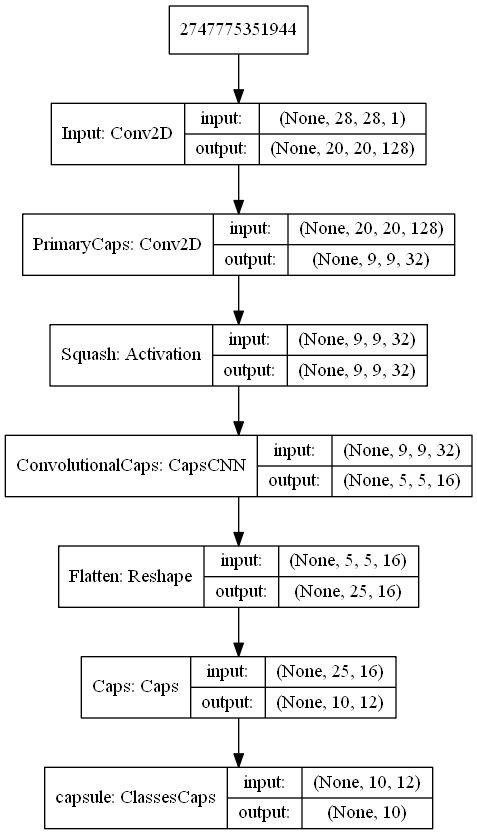

```python
# Plot model graph
plot_model(model, show_shapes=True, show_layer_names=True, to_file='Capsulemnistmodel.png')
from IPython.display import Image
Image(retina=True, filename='Capsulemnistmodel.png')
```

```python
model.summary()
```

```
_________________________________________________________________
Layer (type)                 Output Shape              Param #
=================================================================
Input (Conv2D)               (None, 20, 20, 128)       10496
_________________________________________________________________
PrimaryCaps (Conv2D)         (None, 9, 9, 32)          36896
_________________________________________________________________
Squash (Activation)          (None, 9, 9, 32)          0
_________________________________________________________________
ConvolutionalCaps (CapsCNN)  (None, 5, 5, 16)          12800
_________________________________________________________________
Flatten (Reshape)            (None, 25, 16)            0
_________________________________________________________________
Caps (Caps)                  (None, 10, 12)            48000
_________________________________________________________________
capsule (ClassesCaps)        (None, 10)                0
=================================================================
Total params: 108,192
Trainable params: 108,192
Non-trainable params: 0
_________________________________________________________________
```

# Training

```python
model.compile(optimizer=Adam(lr=1e-3),
              loss=margin(),
              metrics={'capsule': 'categorical_accuracy'})
```

```python
%%time

hist = model.fit_generator(trainGenerator,
                           steps_per_epoch=trainGenerator.n // trainGenerator.batch_size,
                           epochs=10,
                           validation_data=testGenerator,
                           validation_steps=testGenerator.n // testGenerator.batch_size,
                           workers=4,
                           verbose=1)
```

```
Wall time: 24min 12s
```

```python
model.save('Capsulemnistmodel.h5')  # creates a HDF5 file 'my_model.h5'
```

```python
hist.history['loss']
```

```
[0.27788798355972394,
 0.02551282823372021,
 0.018125380394468083,
 0.014462192015430432,
 0.012600422554029015,
 0.011040692468667013,
 0.009997623616079374,
 0.00941389360834013,
 0.008490020013523185,
 0.0080096039464244]
```

```python
hist.history['categorical_accuracy']
```

```
[0.6567666666666667,
 0.97485,
 0.9813833333333334,
 0.9849,
 0.98665,
 0.9886166666666667,
 0.9893166666666666,
 0.9902833333333333,
 0.9914666666666667,
 0.9918666666666667]
```

```python
hist.history['val_loss']
```

```
[0.022467026306549086,
 0.013454704394326836,
 0.011589761738208472,
 0.01140455871756801,
 0.008844918888166286,
 0.00779906499529825,
 0.0076018994957616085,
 0.007508251885198843,
 0.007285568096643328,
 0.0073961114696807955]
```

```python
hist.history['val_categorical_accuracy']
```

```
[0.9789, 0.9859, 0.9873, 0.9877, 0.9908, 0.9923, 0.9929, 0.9911, 0.9927, 0.992]
```

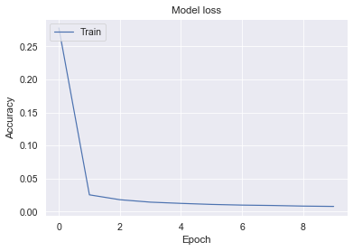

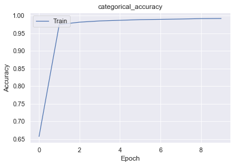

[figure not shown]

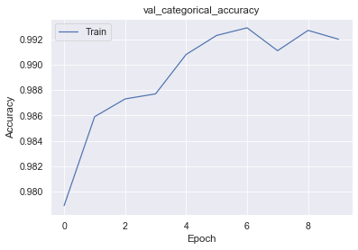

```python
import matplotlib.pyplot as plt


# Plot training & validation accuracy values
fig=plt.figure()
plt.plot(hist.history['loss'])
# plt.plot(hist.history['val_acc'])
# fig=plt.figure()
plt.title('Model loss')
plt.ylabel('Accuracy')
plt.xlabel('Epoch')
plt.legend(['Train', 'Test'], loc='upper left')
plt.show()

fig.savefig('Capsulefashion_mnistmodel.png')


fig=plt.figure()
plt.plot(hist.history['categorical_accuracy'])
# plt.plot(hist.history['val_acc'])

plt.title('categorical_accuracy')
plt.ylabel('Accuracy')
plt.xlabel('Epoch')
plt.legend(['Train', 'Test'], loc='upper left')
plt.show()
fig.savefig('Capsulefashion_mnistmode2.png')

fig=plt.figure()
plt.plot(hist.history['val_loss'])
# plt.plot(hist.history['val_acc'])

plt.title('val_loss')
plt.ylabel('Accuracy')
plt.xlabel('Epoch')
plt.legend(['Train', 'Test'], loc='upper left')
plt.show()
fig.savefig('Capsulefashion_mnistmode3.png')

fig=plt.figure()
plt.plot(hist.history['val_categorical_accuracy'])
# plt.plot(hist.history['val_acc'])

plt.title('val_categorical_accuracy')
plt.ylabel('Accuracy')
plt.xlabel('Epoch')
plt.legend(['Train', 'Test'], loc='upper left')
plt.show()
fig.savefig('Capsulefashion_mnistmode4.png')
```

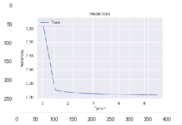

```python
import matplotlib.image as img
im1 =img.imread('Capsulefashion_mnistmodel.png')
plt.imshow(im1)
```

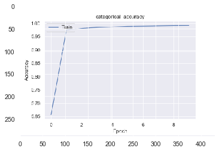

```python
import matplotlib.image as img
im1 =img.imread('Capsulefashion_mnistmode2.png')
plt.imshow(im1)
```

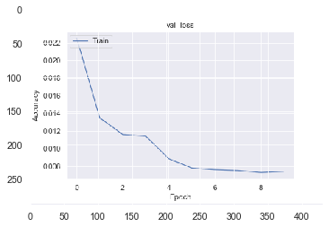

```python
import matplotlib.image as img
im1 =img.imread('Capsulefashion_mnistmode3.png')
plt.imshow(im1)
```

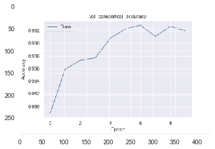

```python
import matplotlib.image as img
im1 =img.imread('Capsulefashion_mnistmode4.png')
plt.imshow(im1)
```

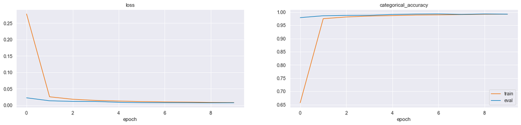

```python
plotHistory(hist.history)
plt.savefig('Capsulemnistmodel.png')
```